# Experiment Report

This report presents the analysis for **lr_xval_subgroups_with_int_ids_model**: Cross-validation with subgroups using a LinearRegression model.

Mon Dec 5 10:18:39 2022

## Overall descriptive feature statistics

These values are reported before transformations.

|  | mean | std. dev. | min | max | skewness | kurtosis | Correlation | p | N |
| --- | --- | --- | --- | --- | --- | --- | --- | --- | --- |
| FEATURE1 | 5.218 | 0.523 | 3.172 | 6.622 | -0.439 | 4.620 | 0.576 | 0.000 | 500 |
| FEATURE2 | -0.099 | 0.029 | -0.252 | -0.052 | -1.637 | 8.824 | 0.338 | 0.000 | 500 |
| FEATURE3 | -0.182 | 0.075 | -0.412 | -0.056 | -0.421 | 3.023 | 0.510 | 0.000 | 500 |
| FEATURE4 | -0.191 | 0.152 | -0.629 | 0.002 | -0.280 | 2.427 | 0.488 | 0.000 | 500 |
| FEATURE5 | -0.097 | 0.041 | -0.195 | 0.002 | 0.208 | 3.188 | 0.330 | 0.000 | 500 |
| FEATURE6 | 4.448 | 0.300 | 3.213 | 5.144 | -0.804 | 4.800 | 0.253 | 0.000 | 500 |
| FEATURE7 | 10.668 | 5.734 | 1.000 | 20.000 | -0.012 | 1.845 | -0.069 | 0.123 | 500 |
| FEATURE8 | -8484.540 | 2530.851 | -13950.786 | -2680.403 | 0.036 | 2.071 | -0.105 | 0.018 | 500 |

### Prevalence of recoded cases

This sections shows the number and percentage of cases truncated to mean +/- 4 SD for each feature.

[figure not shown]

### Feature value distribution

The following table shows additional statistics for the data. Quantiles are computed using type=3 method used in SAS. The mild outliers are defined as data points between [1.5, 3) * IQR away from the nearest quartile. Extreme outliers are the data points >= 3 * IQR away from the nearest quartile.

|  | 1% | 5% | 25% | 50% | 75% | 95% | 99% | IQR | Mild outliers | Extreme outliers |
| --- | --- | --- | --- | --- | --- | --- | --- | --- | --- | --- |
| FEATURE1 | 3.245 | 4.442 | 4.949 | 5.234 | 5.500 | 6.083 | 6.457 | 0.551 | 18 | 5 |
| FEATURE2 | -0.245 | -0.146 | -0.115 | -0.095 | -0.079 | -0.061 | -0.058 | 0.035 | 5 | 5 |
| FEATURE3 | -0.408 | -0.316 | -0.232 | -0.189 | -0.121 | -0.070 | -0.060 | 0.110 | 5 | 0 |
| FEATURE4 | -0.622 | -0.452 | -0.302 | -0.201 | -0.001 | 0.001 | 0.002 | 0.301 | 0 | 0 |
| FEATURE5 | -0.190 | -0.161 | -0.125 | -0.096 | -0.072 | -0.001 | 0.001 | 0.053 | 0 | 0 |
| FEATURE6 | 3.288 | 3.896 | 4.281 | 4.489 | 4.631 | 4.881 | 5.061 | 0.351 | 8 | 2 |
| FEATURE7 | 1.000 | 2.000 | 6.000 | 10.000 | 16.000 | 19.000 | 20.000 | 10.000 | 0 | 0 |
| FEATURE8 | -13385.395 | -12497.212 | -10498.892 | -8566.848 | -6375.795 | -4419.712 | -3711.225 | 4123.097 | 0 | 0 |

Feature values by QUESTION

In all plots in this subsection the values are reported before transformations/truncation. The lines indicate the threshold for truncation (mean +/- 4*SD).

[figure not shown]

Feature values by L1

In all plots in this subsection the values are reported before transformations/truncation. The lines indicate the threshold for truncation (mean +/- 4*SD).

[figure not shown]

## Feature distributions and inter-feature correlations

### Training set distributions

The following plot shows the distributions of the feature values in the training set, after transformation (if applicable), truncation and standardization (if applicable). The line shows the kernel density estimate. The human score (`sc1`) is also included.

Response length (`length`) is included if you specified `length_column` in the config file, unless the column had missing values or a standard deviation <= 0.

[figure not shown]

### Inter-feature correlations

The following table shows the Pearson correlations between all the training features after transformation (if applicable), truncation and standardization (if applicable). The human score (`sc1`) is also included.

Response length (`length`) is included if you specified `length_column` in the config file, unless the column had missing values or a standard deviation <= 0.

The following values are highlighted:

- inter-feature correlations above 0.7, and
- `sc1`-feature correlations lower than 0.1 or higher than 0.7

|  | sc1 | FEATURE1 | FEATURE2 | FEATURE3 | FEATURE4 | FEATURE5 | FEATURE6 | FEATURE7 | FEATURE8 |
| --- | --- | --- | --- | --- | --- | --- | --- | --- | --- |
| sc1 | 1.000 | 0.576 | 0.321 | 0.510 | 0.488 | 0.330 | 0.252 | -0.069 | -0.105 |
| FEATURE1 | 0.576 | 1.000 | 0.236 | 0.408 | 0.464 | 0.218 | -0.080 | -0.043 | -0.020 |
| FEATURE2 | 0.321 | 0.236 | 1.000 | 0.370 | 0.316 | 0.397 | 0.200 | -0.005 | -0.077 |
| FEATURE3 | 0.510 | 0.408 | 0.370 | 1.000 | 0.341 | 0.367 | 0.287 | 0.025 | -0.047 |
| FEATURE4 | 0.488 | 0.464 | 0.316 | 0.341 | 1.000 | 0.325 | 0.259 | -0.016 | -0.091 |
| FEATURE5 | 0.330 | 0.218 | 0.397 | 0.367 | 0.325 | 1.000 | 0.267 | -0.006 | -0.083 |
| FEATURE6 | 0.252 | -0.080 | 0.200 | 0.287 | 0.259 | 0.267 | 1.000 | 0.023 | -0.034 |
| FEATURE7 | -0.069 | -0.043 | -0.005 | 0.025 | -0.016 | -0.006 | 0.023 | 1.000 | 0.035 |
| FEATURE8 | -0.105 | -0.020 | -0.077 | -0.047 | -0.091 | -0.083 | -0.034 | 0.035 | 1.000 |

### Marginal and partial correlations

The plot below shows correlations between truncated and standardized (if applicable) values of each feature against human score. The first bar (`Marginal`) in each case shows Pearson's correlation. The second bar (`Partial - all`) shows partial correlations after controlling for all other variables. If you specified `length_column` in the config file, a third bar (`Partial - length`) will show partial correlations of each feature against the human score after controlling for length. The dotted lines correspond to *r* = 0.1 and *r* = 0.7.

[figure not shown]

Differential feature functioning

This section shows differential feature functioning (DFF) plots for all features and subgroups. The features are shown after applying transformations (if applicable) and truncation of outliers.

DFF by QUESTION

[figure not shown]

DFF by L1

[figure not shown]

## Model

Model used: **LinearRegression**

Number of features in model: **8**

Model summary

```
                            OLS Regression Results
==============================================================================
Dep. Variable:                    sc1   R-squared:                       0.497
Model:                            OLS   Adj. R-squared:                  0.489
Method:                 Least Squares   F-statistic:                     60.66
Date:                Mon, 05 Dec 2022   Prob (F-statistic):           1.66e-68
Time:                        10:18:36   Log-Likelihood:                -435.13
No. Observations:                 500   AIC:                             888.3
Df Residuals:                     491   BIC:                             926.2
Df Model:                           8
Covariance Type:            nonrobust
==============================================================================
                 coef    std err          t      P>|t|      [0.025      0.975]
------------------------------------------------------------------------------
const          3.4200      0.026    131.176      0.000       3.369       3.471
FEATURE1       0.3361      0.033     10.269      0.000       0.272       0.400
FEATURE2       0.0345      0.030      1.153      0.249      -0.024       0.093
FEATURE3       0.1702      0.032      5.314      0.000       0.107       0.233
FEATURE4       0.1195      0.032      3.720      0.000       0.056       0.183
FEATURE5       0.0402      0.030      1.332      0.184      -0.019       0.100
FEATURE6       0.1349      0.030      4.553      0.000       0.077       0.193
FEATURE7      -0.0454      0.026     -1.733      0.084      -0.097       0.006
FEATURE8      -0.0483      0.026     -1.836      0.067      -0.100       0.003
==============================================================================
Omnibus:                        9.067   Durbin-Watson:                   2.317
Prob(Omnibus):                  0.011   Jarque-Bera (JB):               12.045
Skew:                          -0.170   Prob(JB):                      0.00242
Kurtosis:                       3.681   Cond. No.                         2.61
==============================================================================

Notes:
[1] Standard Errors assume that the covariance matrix of the errors is correctly specified.
```

Model fit

| N responses | N features | R2 | R2_adjusted |
| --- | --- | --- | --- |
| 500 | 8 | 0.497 | 0.489 |

### Standardized and relative regression coefficients (betas)

The relative coefficients are intended to show relative contribution of different feature and their primary purpose is to indentify whether one of the features has an unproportionate effect over the final score. They are computed as standardized/(sum of absolute values of standardized coefficients).

Negative standardized coefficients are highlighted.

**Note**: if the model contains negative coefficients, relative values will not sum up to one and their interpretation is generally questionable.

| feature | standardized | relative |
| --- | --- | --- |
| FEATURE1 | 0.412 | 0.362 |
| FEATURE2 | 0.042 | 0.037 |
| FEATURE3 | 0.209 | 0.183 |
| FEATURE4 | 0.147 | 0.129 |
| FEATURE5 | 0.049 | 0.043 |
| FEATURE6 | 0.165 | 0.145 |
| FEATURE7 | -0.056 | -0.049 |
| FEATURE8 | -0.059 | -0.052 |

Here are the same values, shown graphically.

[figure not shown]

Model diagnostics

These are standard plots for model diagnostics for the main model. All information is computed based on the training set.

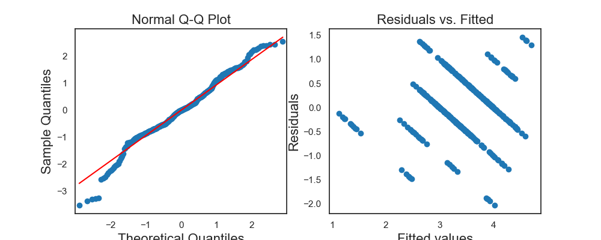

## Links to intermediate files

Click on the hyperlinks below to see the intermediate experiment files generated as part of this experiment.

**Betas**: csv

**Coefficients**: csv

**Coefficients Scaled**: csv

**Confmatrix**: csv

**Cors Orig**: csv

**Cors Processed**: csv

**Data Composition**: csv

**Data Composition By L1**: csv

**Data Composition By Question**: csv

**Eval**: csv

**Eval By L1**: csv

**Eval By Question**: csv

**Eval Short**: csv

**Feature**: csv

**Feature Descriptives**: csv

**Feature Descriptivesextra**: csv

**Feature Outliers**: csv

**Margcor Score All Data**: csv

**Margcor Score By L1**: csv

**Margcor Score By Question**: csv

**Model Fit**: csv

**Pca**: csv

**Pcavar**: csv

**Pcor Score All Data**: csv

**Pcor Score By L1**: csv

**Pcor Score By Question**: csv

**Postprocessing Params**: csv

**Pred Processed**: csv

**Pred Train**: csv

**Score Dist**: csv

**Test Excluded Composition**: csv

**Test Features**: csv

**Test Metadata**: csv

**Test Other Columns**: csv

**Test Preprocessed Features**: csv

**Train Excluded Composition**: csv

**Train Features**: csv

**Train Metadata**: csv

**Train Other Columns**: csv

**Train Preprocessed Features**: csv

## System information

This report was generated using rsmtool v9.0.0 on a 64bit computer running Mac OS X.

### Python packages

[output not shown]

[output cut: 93 more lines]

[output not shown]